# TP modèles linéaires généralisés - Correction

4modIA - 2021-2022

Ce TP a pour but la révision des notions vues en modèle linéaire généralisé. Je vous invite à écrire les modèles, les tests, … mis en oeuvre tout le long du TP.  
Ce TP nécessite les librairies R suivantes :

```r
library(bestglm)
library(ggfortify)
library(ggplot2)
library(gridExtra)
library(VGAM)
library(ROCR)
library(tidyverse)
library(pROC)
```

# 1 Régression logistique

Dans cette section, nous allons nous intéresser au jeu de données `SAheart` disponible dans la librairie **bestglm**. On souhaite expliquer la présence/absence d’une maladie cardiovasculaire (*chd*) en fonction de 9 variables et on dispose pour cela d’un échantillon de $n=462$ individus.

```r
data(SAheart)
SAheart$chd<-as.factor(SAheart$chd)
```

## 1.1 Statistiques descriptives

*Question : Dans un premier temps, lisez la description des données disponible dans l’aide de R (tapez `? SAheart` dans la console). Faites une étude de statistique descriptive pour vous familiariser avec le jeu de données.*

Le jeu de données est composé des variables suivantes :

1. sbp: pression artérielle systolique
2. tabac: tabac cumulatif (kg)
3. ldl: cholestérol des lipoprotéines de basse densité
4. adiposité
5. famhist: antécédents familiaux de maladie cardiaque (Présent, Absent)
6. type: comportement de type-A
7. obésité
8. alcool: consommation actuelle d’alcool
9. âge: âge au début
10. chd: réponse, maladie coronarienne

```r
str(SAheart)
```

```
'data.frame':   462 obs. of  10 variables:
 $ sbp      : int  160 144 118 170 134 132 142 114 114 132 ...
 $ tobacco  : num  12 0.01 0.08 7.5 13.6 6.2 4.05 4.08 0 0 ...
 $ ldl      : num  5.73 4.41 3.48 6.41 3.5 6.47 3.38 4.59 3.83 5.8 ...
 $ adiposity: num  23.1 28.6 32.3 38 27.8 ...
 $ famhist  : Factor w/ 2 levels "Absent","Present": 2 1 2 2 2 2 1 2 2 2 ...
 $ typea    : int  49 55 52 51 60 62 59 62 49 69 ...
 $ obesity  : num  25.3 28.9 29.1 32 26 ...
 $ alcohol  : num  97.2 2.06 3.81 24.26 57.34 ...
 $ age      : int  52 63 46 58 49 45 38 58 29 53 ...
 $ chd      : Factor w/ 2 levels "0","1": 2 2 1 2 2 1 1 2 1 2 ...
```

```r
summary(SAheart)
```

```
      sbp           tobacco             ldl           adiposity
 Min.   :101.0   Min.   : 0.0000   Min.   : 0.980   Min.   : 6.74
 1st Qu.:124.0   1st Qu.: 0.0525   1st Qu.: 3.283   1st Qu.:19.77
 Median :134.0   Median : 2.0000   Median : 4.340   Median :26.11
 Mean   :138.3   Mean   : 3.6356   Mean   : 4.740   Mean   :25.41
 3rd Qu.:148.0   3rd Qu.: 5.5000   3rd Qu.: 5.790   3rd Qu.:31.23
 Max.   :218.0   Max.   :31.2000   Max.   :15.330   Max.   :42.49
    famhist        typea         obesity         alcohol            age
 Absent :270   Min.   :13.0   Min.   :14.70   Min.   :  0.00   Min.   :15.00
 Present:192   1st Qu.:47.0   1st Qu.:22.98   1st Qu.:  0.51   1st Qu.:31.00
               Median :53.0   Median :25.80   Median :  7.51   Median :45.00
               Mean   :53.1   Mean   :26.04   Mean   : 17.04   Mean   :42.82
               3rd Qu.:60.0   3rd Qu.:28.50   3rd Qu.: 23.89   3rd Qu.:55.00
               Max.   :78.0   Max.   :46.58   Max.   :147.19   Max.   :64.00
 chd
 0:302
 1:160
```

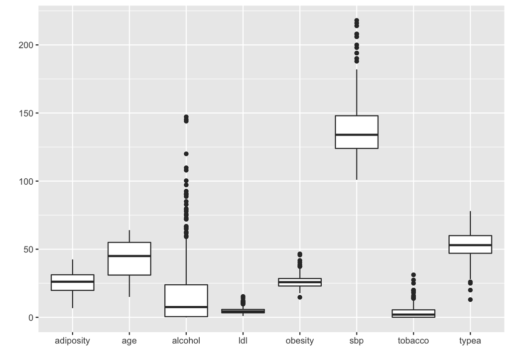

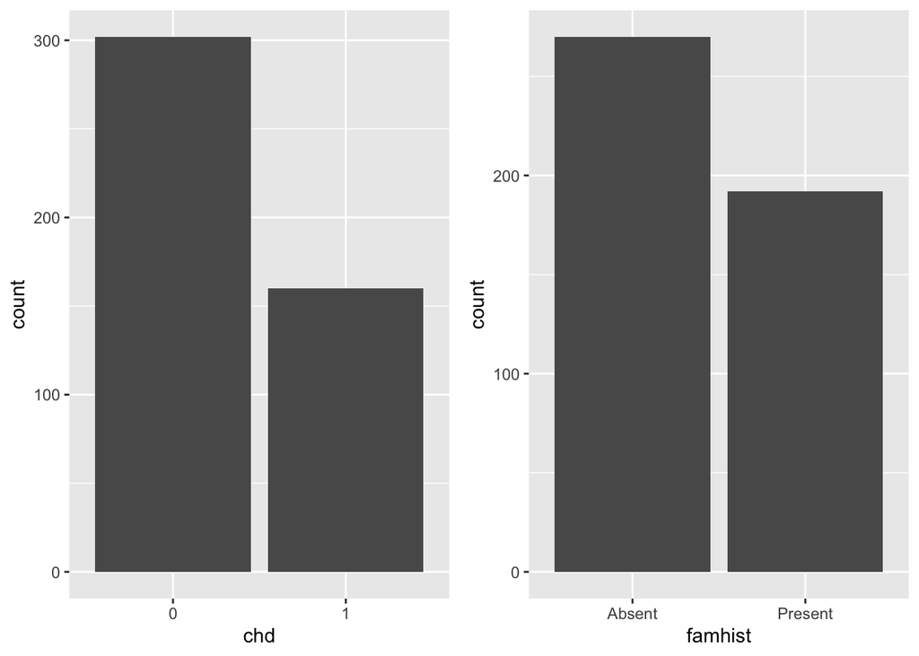

## 1.2 Etude de *chd* en fonction de la variable *ldl*

**Question 1.** Proposez un modèle pour expliquer *chd* en fonction de *ldl* et programmez-le à l’aide de la fonction `glm()`.

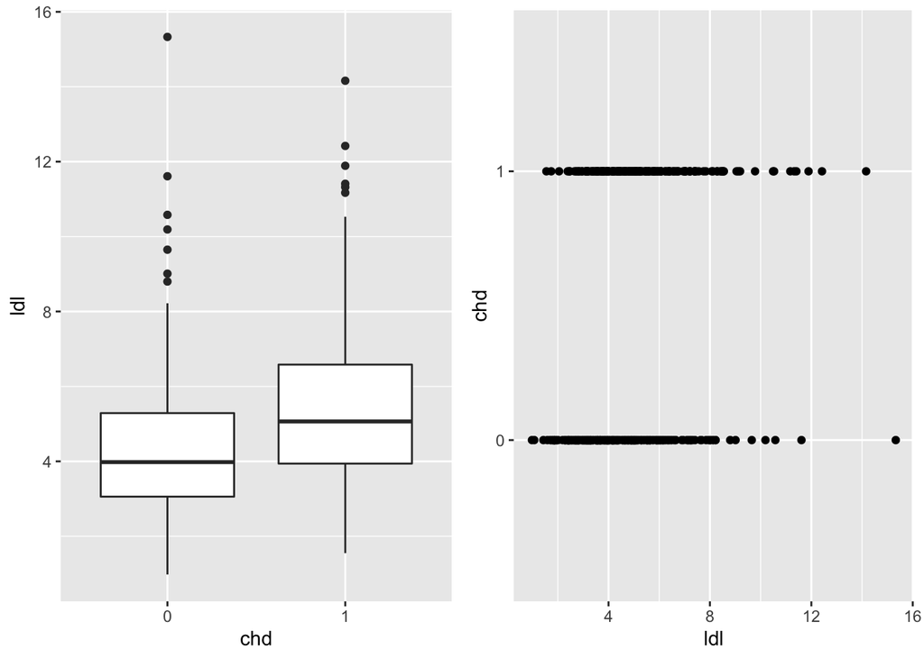

```r
g1=ggplot(SAheart,aes(x=chd,y=ldl))+
  geom_boxplot()
g2=ggplot(SAheart,aes(y=chd,x=ldl))+
  geom_point()
grid.arrange(g1,g2,ncol=2)
```

On ajuste un modèle de régression logistique simple :
$$chd_i | ldl_i \sim \mathcal{B}(\pi_i) \textrm{ et }
g(\pi_i) = \mbox{logit}(\pi_i) = \ln\left(\frac{\pi_i}{1-\pi_i}\right) =
\theta_0 + \theta_1\ ldl_i$$

```r
chd_ldl = glm(chd ~ ldl, data = SAheart, family = binomial)
summary(chd_ldl)
```

```
Call:
glm(formula = chd ~ ldl, family = binomial, data = SAheart)

Deviance Residuals:
    Min       1Q   Median       3Q      Max
-2.1647  -0.8948  -0.7426   1.2688   1.8637

Coefficients:
            Estimate Std. Error z value Pr(>|z|)
(Intercept) -1.96867    0.27308  -7.209 5.63e-13 ***
ldl          0.27466    0.05164   5.319 1.04e-07 ***
---
Signif. codes:  0 '***' 0.001 '**' 0.01 '*' 0.05 '.' 0.1 ' ' 1

(Dispersion parameter for binomial family taken to be 1)

    Null deviance: 596.11  on 461  degrees of freedom
Residual deviance: 564.28  on 460  degrees of freedom
AIC: 568.28

Number of Fisher Scoring iterations: 4
```

**Question 2.** A l’aide des sorties de `chd_ldl`, calculez le pseudoR2 associé à ce modèle et commentez.

```r
pseudoR2 = 1-(chd_ldl$deviance / chd_ldl$null.deviance)
```

Le pseudo-$R^2$ vaut 0.0534 pour le modèle $chd\_ldl$ ce qui est très faible.

**Question 3.** Testez la nullité de chacun des paramètres dans ce modèle par deux méthodes différentes et concluez à l’aide des sorties de R.

**Méthode 1 : Test de nullité de chacun des paramètres par le $Z$-test**

On repart de $(\widehat{\theta}_j) / \sqrt{(I_n(\widehat{\theta})^{-1})_{jj}}$ converge en loi vers $\mathcal{N}(0,1)$ sous $H_0$ pour construire le Z-test.Cf slides de cours pour la construction détaillée (à savoir refaire).

```r
coef(summary(chd_ldl))
```

```
              Estimate Std. Error   z value     Pr(>|z|)
(Intercept) -1.9686681 0.27307908 -7.209150 5.630207e-13
ldl          0.2746613 0.05163983  5.318787 1.044615e-07
```

On rejette la nullité de chacun des paramètres (pvaleur $<0.05$).

**Méthode 2 : Test de sous-modèle**

- Tester la nullité du paramètre $\theta_1$ revient à tester le modèle constant contre modèle complet.

$$[M_0] : \hspace{0.5 cm} g(\pi_i) = \mbox{logit}(\pi_i) = \theta_0$$

```r
anova(glm(chd~1,data=SAheart,family="binomial"),chd_ldl,test="Chisq")
```

```
Analysis of Deviance Table

Model 1: chd ~ 1
Model 2: chd ~ ldl
  Resid. Df Resid. Dev Df Deviance  Pr(>Chi)
1       461     596.11
2       460     564.28  1    31.83 1.683e-08 ***
---
Signif. codes:  0 '***' 0.001 '**' 0.01 '*' 0.05 '.' 0.1 ' ' 1
```

Pour le modèle nul, on a $k_0=1$ paramètre donc $n-k_0 = 462-1=461$  
Pour le modèle chd_mod_ldl, $k_1=2$ donc $n-k_1=462-2=460$  
La différence des déviances $\mathcal{D}(M_0)-\mathcal{D}(M_1)$ converge en loi vers un $\chi^2(2-1)$.

- Tester la nullité du paramètre $\theta_0$ revient à tester le modèle sans intercept contre modèle complet

$$[M_2] : \hspace{0.5cm} g(\pi_i) = \mbox{logit}(\pi_i) = \theta_1 ldl_i$$

```r
anova(glm(chd~ldl -1 ,data=SAheart,family="binomial"),chd_ldl,test="Chisq")
```

```
Analysis of Deviance Table

Model 1: chd ~ ldl - 1
Model 2: chd ~ ldl
  Resid. Df Resid. Dev Df Deviance  Pr(>Chi)
1       461     625.07
2       460     564.28  1   60.789 6.353e-15 ***
---
Signif. codes:  0 '***' 0.001 '**' 0.01 '*' 0.05 '.' 0.1 ' ' 1
```

**Question 4.** Construisez un intervalle de confiance au niveau de confiance de $95\%$ pour les paramètres de ce modèle et programmez-les à l’aide des fonctions `confint()` et `confint.default()`.

- Intervalle de confiance par Wald : $(\widehat{\theta}_j - \theta_j) / \sqrt{(I_n(\widehat{\theta})^{-1})_{jj}}$ converge en loi vers $\mathcal{N}(0,1)$ puis construction d’un IC asymptotique (cf Slides de cours pour détails de construction).

```r
confint.default(chd_ldl)
```

```
                 2.5 %     97.5 %
(Intercept) -2.5038933 -1.4334430
ldl          0.1734491  0.3758735
```

- Intervalle de confiance par la méthode du rapport de vraisemblance : (La construction est hors programme)

```r
confint(chd_ldl)
```

```
                 2.5 %     97.5 %
(Intercept) -2.5190571 -1.4468069
ldl          0.1760264  0.3788656
```

**Question 5.** Interprétez le paramètre associé à la variable *ldl* à l’aide d’odds et/ou d’odds ratio.

```r
expc = exp(chd_ldl$coefficients)
print(expc)
```

```
(Intercept)         ldl
  0.1396427   1.3160848
```

$OR(ldl+1,ldl)=\frac{odds(ldl+1)}{odds(ldl)} = \frac{\exp(\theta_0 + \theta_1 (ldl+1))}{\exp(\theta_0 + \theta_1 (ldl))} =\exp(\theta_1)=$ 1.3161 : l’augmentation d’une unité de ldl augmente de 1.3161 fois le risque d’un homme de faire un infractus.

**Question 6.** Que permettent d’obtenir les deux commandes suivantes ?

On considère un nouvel individu ayant la valeur $ldl_0=4.75$.

```r
predict(chd_ldl,newdata=data.frame(ldl=4.75),type="response")
```

```
        1
0.3398356
```

```r
predict(chd_ldl,newdata=data.frame(ldl=4.75),type="link")
```

```
         1
-0.6640271
```

```r
a=chd_ldl$coefficients[1]+chd_ldl$coefficients[2]*4.75
print(a)
```

```
(Intercept)
 -0.6640271
```

```r
exp(a)/(1+exp(a))
```

```
(Intercept)
  0.3398356
```

**Question 7.** Déterminez les valeurs ajustées à l’aide de la fonction `predict()`. Comparez les valeurs ajustées avec les vraies valeurs de *chd* par une table de contingence (vous pouvez utiliser la fonction `table()`).

Les valeurs ajustées sont données par $\widehat{Y}_i =\mathbb{1}_{\widehat{\pi}_i > 0.5}$.

On les compare avec les vraies valeurs $Y_i = chd_i$.

```r
hatY <- (chd_ldl$fitted.values > 0.5)
table(SAheart$chd,hatY)
```

```
   hatY
    FALSE TRUE
  0   277   25
  1   129   31
```

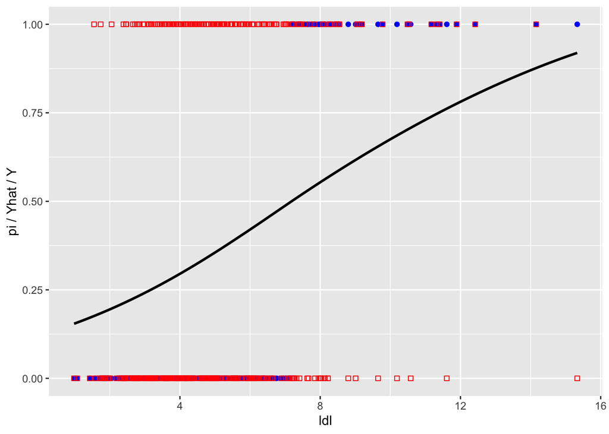

```r
pihat<-predict(chd_ldl,type="response")
df1<-data.frame(ldl=SAheart$ldl,pihat=pihat,Yihat=as.numeric(pihat>0.5),Yi=as.numeric(SAheart$chd)-1)
ggplot(df1)+
  geom_point(aes(x=ldl,y=Yihat),col="blue")+
  geom_smooth(aes(x=ldl,y=pihat),col="black")+
  geom_point(aes(x=ldl,y=Yi),col="red",shape=0)+
  xlab("ldl")+
  ylab("pi / Yhat / Y")
```

Les carrés rouge sont les vraies valeurs et les ronds bleus les valeurs prédites à partir des valeurs des $\hat\pi_i$ (représentés par la courbe noire). On peut remarquer que la prédiction n’est pas très bonne.

## 1.3 Etude de *chd* en fonction de la variable *famhist*

**Question 1.** Proposez un modèle pour expliquer *chd* en fonction de *famhist* et programmez-le à l’aide de la fonction `glm()`.

On ajuste un modèle de régression logistique simple pour expliquer la variable binaire $chd$ par rapport à la variable qualitative $famhist$ :

$$chd_i \sim \mathcal{B}(\pi_i) \hspace{0.5cm} \textrm{ et }
\hspace{0.5cm} g(\pi_i) = \ln(\pi_i/ 1-\pi_i) = \theta_0 + \theta_1
\mathbb{1}_{famhist_i=1}$$

```r
table(SAheart$chd,SAheart$famhist)
```

```
    Absent Present
  0    206      96
  1     64      96
```

```r
chd_famhist<-glm(chd~famhist,data=SAheart,family="binomial")
summary(chd_famhist)
```

```
Call:
glm(formula = chd ~ famhist, family = "binomial", data = SAheart)

Deviance Residuals:
    Min       1Q   Median       3Q      Max
-1.1774  -0.7356  -0.7356   1.1774   1.6968

Coefficients:
               Estimate Std. Error z value Pr(>|z|)
(Intercept)     -1.1690     0.1431  -8.169 3.12e-16 ***
famhistPresent   1.1690     0.2033   5.751 8.85e-09 ***
---
Signif. codes:  0 '***' 0.001 '**' 0.01 '*' 0.05 '.' 0.1 ' ' 1

(Dispersion parameter for binomial family taken to be 1)

    Null deviance: 596.11  on 461  degrees of freedom
Residual deviance: 561.89  on 460  degrees of freedom
AIC: 565.89

Number of Fisher Scoring iterations: 4
```

Remarque sur le paramétrage pour identifiabilité : $\theta_0$ donne le comportement pour $famhist=0$ et $\theta_0 + \theta_1$ pour $famhist=1$.

**Question 2.** Que remarquez-vous sur l’estimation des paramètres ? Quel est l’impact sur les prédictions ?

Quand on estime les paramètres, on a que $\widehat{\theta}_0 = - \widehat{\theta}_1$. Du coup, on a $\widehat{\pi}(famhist_i=1) = \exp(\widehat{\theta}_0 + \widehat{\theta}_1) / (1+\exp(\widehat{\theta}_0 + \widehat{\theta}_1)) = 0.5$ et $\widehat{\pi}(famhist_i=0) = \exp(\widehat{\theta}_0) / (1+\exp(\widehat{\theta}_0)) = 0.24$.

```r
table(round(chd_famhist$fitted.values,2))
```

```
0.24  0.5
 270  192
```

**Question 3.** Calculez l’odds ratio associé à la variable `famhist` et interprétez.

$odds(famhist_i=0) = \exp(\theta_0)$, $odds(famhist_i=1)=\exp(\theta_0+\theta_1)$ et $OR(famhist_i=1,famhist_i=0,)=\exp(\theta_1)$ :

```r
exp(c(coef(chd_famhist),sum=sum(coef(chd_famhist))))
```

```
   (Intercept) famhistPresent            sum
     0.3106796      3.2187500      1.0000000
```

Une personne ayant un historique de problème cardio dans la famille a 3.22 fois plus de chance d’avoir une maladie cardiovasculaire qu’une personne sans antécédents familiaux.

## 1.4 Etude de *chd* en fonction de toutes les variables explicatives

**Question 1.** Ajustez un modèle de régression logistique multiple additif à l’aide de la fonction `glm()`.

$$chd_i\sim\mathcal{B}(\pi_i)
\textrm{ et }g(\pi_i)=\ln(\pi_i / ( 1-\pi_i)) = \theta_0 +
\sum_{j=1}^{9} \theta_j x_i^{(j)} \textrm{ dont } x_i^{(famhist)} =
\mathbb{1}_{famhist_i = present}$$

```r
modellogit = glm(chd~.,data=SAheart,family=binomial(link="logit"))
summary(modellogit)
```

```
Call:
glm(formula = chd ~ ., family = binomial(link = "logit"), data = SAheart)

Deviance Residuals:
    Min       1Q   Median       3Q      Max
-1.7781  -0.8213  -0.4387   0.8889   2.5435

Coefficients:
                 Estimate Std. Error z value Pr(>|z|)
(Intercept)    -6.1507209  1.3082600  -4.701 2.58e-06 ***
sbp             0.0065040  0.0057304   1.135 0.256374
tobacco         0.0793764  0.0266028   2.984 0.002847 **
ldl             0.1739239  0.0596617   2.915 0.003555 **
adiposity       0.0185866  0.0292894   0.635 0.525700
famhistPresent  0.9253704  0.2278940   4.061 4.90e-05 ***
typea           0.0395950  0.0123202   3.214 0.001310 **
obesity        -0.0629099  0.0442477  -1.422 0.155095
alcohol         0.0001217  0.0044832   0.027 0.978350
age             0.0452253  0.0121298   3.728 0.000193 ***
---
Signif. codes:  0 '***' 0.001 '**' 0.01 '*' 0.05 '.' 0.1 ' ' 1

(Dispersion parameter for binomial family taken to be 1)

    Null deviance: 596.11  on 461  degrees of freedom
Residual deviance: 472.14  on 452  degrees of freedom
AIC: 492.14

Number of Fisher Scoring iterations: 5
```

**Question 2.** Comparez les différentes procédures de sélection de variables mises en place par le code suivant.

- On commence par une procédure de sélection de variables avec la fonction `bestglm()` en utilisant le critère BIC :

```r
modelBIC<-bestglm(SAheart,family=binomial,IC="BIC")
modelBIC$BestModel
```

```
Call:  glm(formula = y ~ ., family = family, data = Xi, weights = weights)

Coefficients:
   (Intercept)         tobacco             ldl  famhistPresent           typea
      -6.44644         0.08038         0.16199         0.90818         0.03712
           age
       0.05046

Degrees of Freedom: 461 Total (i.e. Null);  456 Residual
Null Deviance:      596.1
Residual Deviance: 475.7    AIC: 487.7
```

```r
summary(modelBIC)
```

```
Fitting algorithm:  BIC-glm
Best Model:
            df deviance
Null Model 456 475.6856
Full Model 461 596.1084

    likelihood-ratio test - GLM

data:  H0: Null Model vs. H1: Best Fit BIC-glm
X = 120.42, df = 5, p-value < 2.2e-16
```

Le modèle retenu est
$$logit(\pi_i) = \theta_0 + \theta_1\ tobacco_i + \theta_2\ ldl_i +
\theta_3\ \mathbb{1}_{famhist_i = present} + \theta_4\ typea_i +
\theta_5\ age_i$$

- On fait de même avec le critère AIC :

```r
modelAIC<-bestglm(SAheart,family=binomial,IC="AIC")
modelAIC$BestModel
```

```
Call:  glm(formula = y ~ ., family = family, data = Xi, weights = weights)

Coefficients:
   (Intercept)         tobacco             ldl  famhistPresent           typea
      -6.44644         0.08038         0.16199         0.90818         0.03712
           age
       0.05046

Degrees of Freedom: 461 Total (i.e. Null);  456 Residual
Null Deviance:      596.1
Residual Deviance: 475.7    AIC: 487.7
```

On sélectionne le même modèle.

- On peut aussi faire la procédure de sélection de variables à l’aide de la fonction `step()`. Par défaut, on utilise le critère AIC. On peut voir les étapes de la procédure de sélection backward. On retrouve le même sous-modèle retenu.

```r
step.backward<-step(modellogit)
```

```
Start:  AIC=492.14
chd ~ sbp + tobacco + ldl + adiposity + famhist + typea + obesity +
    alcohol + age

            Df Deviance    AIC
- alcohol    1   472.14 490.14
- adiposity  1   472.55 490.55
- sbp        1   473.44 491.44
<none>           472.14 492.14
- obesity    1   474.23 492.23
- ldl        1   481.07 499.07
- tobacco    1   481.67 499.67
- typea      1   483.05 501.05
- age        1   486.53 504.53
- famhist    1   488.89 506.89

Step:  AIC=490.14
chd ~ sbp + tobacco + ldl + adiposity + famhist + typea + obesity +
    age

            Df Deviance    AIC
- adiposity  1   472.55 488.55
- sbp        1   473.47 489.47
<none>           472.14 490.14
- obesity    1   474.24 490.24
- ldl        1   481.15 497.15
- tobacco    1   482.06 498.06
- typea      1   483.06 499.06
- age        1   486.64 502.64
- famhist    1   488.99 504.99

Step:  AIC=488.55
chd ~ sbp + tobacco + ldl + famhist + typea + obesity + age

          Df Deviance    AIC
- sbp      1   473.98 487.98
<none>         472.55 488.55
- obesity  1   474.65 488.65
- tobacco  1   482.54 496.54
- ldl      1   482.95 496.95
```

[output cut: 11 more lines]

```
- typea    1   484.30 496.30
- ldl      1   484.53 496.53
- famhist  1   490.58 502.58
- age      1   502.11 514.11

Step:  AIC=487.69
chd ~ tobacco + ldl + famhist + typea + age

          Df Deviance    AIC
<none>         475.69 487.69
- ldl      1   484.71 494.71
- typea    1   485.44 495.44
- tobacco  1   486.03 496.03
- famhist  1   492.09 502.09
- age      1   502.38 512.38
```

Pour utiliser le critère BIC avec la fonction `step()`, il faut utiliser la syntaxe suivante :

```r
step.backward<-step(modellogit, direction="backward",k=log(nrow(SAheart)))
```

**Question 3.** Ajustez le modèle retenu par les méthodes de la question précédente.

```r
modelbest<-glm(chd~tobacco + ldl + famhist + typea + age,family=binomial,data=SAheart)
summary(modelbest)
```

```
Call:
glm(formula = chd ~ tobacco + ldl + famhist + typea + age, family = binomial,
    data = SAheart)

Deviance Residuals:
    Min       1Q   Median       3Q      Max
-1.9165  -0.8054  -0.4430   0.9329   2.6139

Coefficients:
               Estimate Std. Error z value Pr(>|z|)
(Intercept)    -6.44644    0.92087  -7.000 2.55e-12 ***
tobacco         0.08038    0.02588   3.106  0.00190 **
ldl             0.16199    0.05497   2.947  0.00321 **
famhistPresent  0.90818    0.22576   4.023 5.75e-05 ***
typea           0.03712    0.01217   3.051  0.00228 **
age             0.05046    0.01021   4.944 7.65e-07 ***
---
Signif. codes:  0 '***' 0.001 '**' 0.01 '*' 0.05 '.' 0.1 ' ' 1

(Dispersion parameter for binomial family taken to be 1)

    Null deviance: 596.11  on 461  degrees of freedom
Residual deviance: 475.69  on 456  degrees of freedom
AIC: 487.69

Number of Fisher Scoring iterations: 5
```

On peut par exemple remarquer que le test de nullité de chacun des coefficients séparement a une pvaleur << 0.05.

**Question 4.** Faites un test de sous-modèle entre *modelbest* et *modellogit* pour conforter l’étude de sélection de variables précédente à l’aide de la commande `anova()`.

```r
anova(modelbest,modellogit,test="LRT")
```

```
Analysis of Deviance Table

Model 1: chd ~ tobacco + ldl + famhist + typea + age
Model 2: chd ~ sbp + tobacco + ldl + adiposity + famhist + typea + obesity +
    alcohol + age
  Resid. Df Resid. Dev Df Deviance Pr(>Chi)
1       456     475.69
2       452     472.14  4   3.5455    0.471
```

```r
anova(modelbest,modellogit,test="Chisq")
```

```
Analysis of Deviance Table

Model 1: chd ~ tobacco + ldl + famhist + typea + age
Model 2: chd ~ sbp + tobacco + ldl + adiposity + famhist + typea + obesity +
    alcohol + age
  Resid. Df Resid. Dev Df Deviance Pr(>Chi)
1       456     475.69
2       452     472.14  4   3.5455    0.471
```

La pvaleur valant 0.471, on ne rejette pas le sous-modèle au risque $5\%$.

Pour le sous-modèle on a $k_0=6$ paramètres à estimer donc $n-k_0=462-6=456$  
Pour le modèle complet on a $k_1=10$ paramètres à estimer donc $n-k_0=462-10=452$  
$\mathcal{D}(M_0) - \mathcal{D}(M_1) \stackrel{\mathcal{L}}{\longrightarrow} \chi^2(k_1-k_0 =4)$

**Question 5.** Comment s’interprètent les différents coefficients de *modelbest* ?

```r
exp(modelbest$coefficients)
```

```
   (Intercept)        tobacco            ldl famhistPresent          typea
   0.001586152    1.083693731    1.175850406    2.479793436    1.037812583
           age
   1.051755195
```

Pour l’interprétation des paramètres, il faut considérer des odds-ratio, attention entre variables qualitatives et quantitatives.

**Question 6.** Ajustez le modèle complet avec interaction

```r
modellogitinter<-glm(chd~(.)^2,data=SAheart,family=binomial(link="logit"))
summary(modellogitinter)
```

```
Call:
glm(formula = chd ~ (.)^2, family = binomial(link = "logit"),
    data = SAheart)

Deviance Residuals:
    Min       1Q   Median       3Q      Max
-2.1061  -0.7706  -0.3450   0.7401   2.4782

Coefficients:
                           Estimate Std. Error z value Pr(>|z|)
(Intercept)              -4.193e+00  1.196e+01  -0.351  0.72590
sbp                       4.612e-02  7.799e-02   0.591  0.55429
tobacco                   6.047e-01  3.490e-01   1.733  0.08318 .
ldl                      -5.913e-01  9.071e-01  -0.652  0.51454
adiposity                -2.345e-01  3.278e-01  -0.715  0.47446
famhistPresent           -7.821e-01  3.092e+00  -0.253  0.80030
typea                     6.485e-02  1.338e-01   0.485  0.62783
obesity                   5.436e-02  6.141e-01   0.089  0.92946
alcohol                   5.555e-02  7.651e-02   0.726  0.46780
age                      -6.573e-02  1.377e-01  -0.477  0.63301
sbp:tobacco               8.262e-04  1.348e-03   0.613  0.53994
sbp:ldl                   3.124e-03  3.743e-03   0.835  0.40392
sbp:adiposity             9.401e-04  1.764e-03   0.533  0.59410
sbp:famhistPresent        1.780e-03  1.358e-02   0.131  0.89572
sbp:typea                -3.991e-05  6.905e-04  -0.058  0.95391
 [ getOption("max.print") est atteint -- 31 lignes omises ]
---
Signif. codes:  0 '***' 0.001 '**' 0.01 '*' 0.05 '.' 0.1 ' ' 1

(Dispersion parameter for binomial family taken to be 1)

    Null deviance: 596.11  on 461  degrees of freedom
Residual deviance: 429.32  on 416  degrees of freedom
AIC: 521.32

Number of Fisher Scoring iterations: 6
```

**Question 7.** Faites une sélection de variables pour déterminer un sous-modèle (appelé *modelbestinter* par la suite) à partir du modèle complet avec interaction.

```r
# Procédures de sélection de variables
modelbestinter = step(modellogitinter,trace=F)
summary(modelbestinter)
```

```
Call:
glm(formula = chd ~ tobacco + ldl + adiposity + famhist + typea +
    obesity + alcohol + age + tobacco:typea + tobacco:alcohol +
    ldl:famhist + adiposity:famhist + adiposity:obesity + adiposity:alcohol +
    famhist:alcohol + famhist:age + typea:alcohol, family = binomial(link = "logit"),
    data = SAheart)

Deviance Residuals:
    Min       1Q   Median       3Q      Max
-1.9785  -0.7584  -0.3877   0.7921   2.4202

Coefficients:
                           Estimate Std. Error z value Pr(>|z|)
(Intercept)              -2.6958723  3.0621569  -0.880  0.37865
tobacco                   0.2655371  0.1424776   1.864  0.06236 .
ldl                       0.0021452  0.0805098   0.027  0.97874
adiposity                -0.0625548  0.0889316  -0.703  0.48180
famhistPresent           -1.3447258  1.1842409  -1.136  0.25616
typea                     0.0763677  0.0195327   3.910 9.24e-05 ***
obesity                  -0.2720179  0.1273194  -2.137  0.03264 *
alcohol                   0.1042671  0.0450785   2.313  0.02072 *
age                       0.0365342  0.0153344   2.382  0.01720 *
tobacco:typea            -0.0039988  0.0026317  -1.519  0.12865
tobacco:alcohol           0.0018446  0.0012460   1.480  0.13877
ldl:famhistPresent        0.4386363  0.1328449   3.302  0.00096 ***
adiposity:famhistPresent -0.0687422  0.0408413  -1.683  0.09235 .
adiposity:obesity         0.0063060  0.0035473   1.778  0.07546 .
adiposity:alcohol        -0.0025762  0.0009808  -2.627  0.00862 **
 [ getOption("max.print") est atteint -- 3 lignes omises ]
---
Signif. codes:  0 '***' 0.001 '**' 0.01 '*' 0.05 '.' 0.1 ' ' 1

(Dispersion parameter for binomial family taken to be 1)

    Null deviance: 596.11  on 461  degrees of freedom
Residual deviance: 442.07  on 444  degrees of freedom
AIC: 478.07

Number of Fisher Scoring iterations: 5
```

**Question 8.** Proposez plusieurs méthodes pour comparer les modèles *modellogit*, *modelbest*, *modelbestinter* et *modellogitinter*.

```r
anova(modelbestinter,modellogitinter,test="Chisq")
```

```
Analysis of Deviance Table

Model 1: chd ~ tobacco + ldl + adiposity + famhist + typea + obesity +
    alcohol + age + tobacco:typea + tobacco:alcohol + ldl:famhist +
    adiposity:famhist + adiposity:obesity + adiposity:alcohol +
    famhist:alcohol + famhist:age + typea:alcohol
Model 2: chd ~ (sbp + tobacco + ldl + adiposity + famhist + typea + obesity +
    alcohol + age)^2
  Resid. Df Resid. Dev Df Deviance Pr(>Chi)
1       444     442.07
2       416     429.32 28   12.755   0.9939
```

```r
anova(modelbest,modelbestinter,test="Chisq")
```

```
Analysis of Deviance Table

Model 1: chd ~ tobacco + ldl + famhist + typea + age
Model 2: chd ~ tobacco + ldl + adiposity + famhist + typea + obesity +
    alcohol + age + tobacco:typea + tobacco:alcohol + ldl:famhist +
    adiposity:famhist + adiposity:obesity + adiposity:alcohol +
    famhist:alcohol + famhist:age + typea:alcohol
  Resid. Df Resid. Dev Df Deviance  Pr(>Chi)
1       456     475.69
2       444     442.07 12   33.614 0.0007757 ***
---
Signif. codes:  0 '***' 0.001 '**' 0.01 '*' 0.05 '.' 0.1 ' ' 1
```

```r
modelbest$aic
```

```
[1] 487.6856
```

```r
modellogitinter$aic
```

```
[1] 521.3156
```

```r
modelbestinter$aic
```

```
[1] 478.0712
```

```r
modellogit$aic
```

```
[1] 492.14
```

## 1.5 Pouvoir de prédiction d’un modèle

Pour un modèle $M$ donné, on construit une règle de classification $\hat C_M: x\in\mathbb{R}^p \mapsto \{0,1\}$, qui à des valeurs pour les variables explicatives, associe une valeur pour la réponse (ici binaire). Un critère classique pour mesurer la performance de prédiction de $M$ est la probabilité d’erreur $L(\hat C_M)=\mathbb P(\hat C_M(X)\neq Y)$ qui est inconnue. Si on utilise l’échantillon complet $\mathcal D=(X_i,Y_i)_{i=1,\ldots,n}$ pour construire $\hat C_M$ et estimer $L(\hat C_M)$, on va avoir tendance à sous-estimer $L(\hat C_M)$. Une solution est de découper l’échantillon $\mathcal D$ en un échantillon d’apprentissage $\mathcal D_A$ et un échantillon test $\mathcal D_T$. On utilise $\mathcal D_A$ pour construire $\hat C_M$ et on estime la probabilité d’erreur à l’aide de l’échantillon $\mathcal D_T$ par
$$\frac{1}{card(\mathcal D_T)} \sum_{i\in\mathcal D_T}
\mathbb{1}_{\hat C_M(X_i)\neq Y_i}.$$
Dans le cadre de la régression logistique, $\hat C_M(x)=1$ si $\hat \pi(x) > s$ et $0$ sinon, où $s$ est un seuil à choisir (classiquement $s=0.5$).

**Question 1.**

```r
l<-300
perm<-sample(nrow(SAheart))
# Data apprentissage
dapp<-SAheart[perm[1:l],]
# Data test
dtest<-SAheart[-perm[1:l],]

modelapp1<-glm(chd~tobacco + ldl + famhist + typea + age,family=binomial,data=dapp)
prev1<-predict(modelapp1,newdata=dtest,type="response")
mean(as.numeric(prev1>0.5)!=dtest$chd)
```

```
[1] 0.2654321
```

```r
modelapp2<-glm(chd~.,family=binomial,data=dapp)
prev2<-predict(modelapp2,newdata=dtest,type="response")
mean(as.numeric(prev2>0.5)!=dtest$chd)
```

```
[1] 0.2654321
```

```r
modelapp3<-glm(chd~1,family=binomial,data=dapp)
prev3<-predict(modelapp3,newdata=dtest,type="response")
mean(as.numeric(prev3>0.5)!=dtest$chd)
```

```
[1] 0.3765432
```

```r
modelapp4<-glm(formula = chd ~ tobacco + ldl + adiposity + famhist + typea +
    obesity + alcohol + age + tobacco:typea + tobacco:alcohol +
    ldl:famhist + adiposity:famhist + adiposity:obesity + adiposity:alcohol +
    famhist:alcohol + famhist:age + typea:alcohol, family = binomial(link = "logit"),
    data = dapp)
prev4<-predict(modelapp4,newdata=dtest,type="response")
mean(as.numeric(prev4>0.5)!=dtest$chd)
```

```
[1] 0.2716049
```

**Question 2.** La courbe ROC

Un autre indicateur classiquement utilisé pour comparer des modèles est la courbe ROC. Il est plus flexible car ne dépend pas du choix du seuil $s$. A l’aide de l’échantillon d’apprentissage $\mathcal D_A$, on construit une fonction score $S(x)$. Pour un seuil $s\in[0,1]$, la règle de décision est
$$\hat Y_s = 1 \textrm{ si } S(x)>s,\ 0 \textrm{ sinon}.$$
On peut alors construire la matrice de confusion pour les prédictions sur l’échantillon test $\mathcal D_T$ :

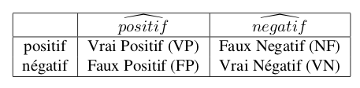

On définit alors deux quantités :

- TPR(s) = taux de vrais positifs = VP(s) / Positifs
- FPR(s) = taux de faux positifs = FP(s) / Négatifs

Le principe de la courbe ROC est de faire varier le seuil $s$ et on trace TPR(s) en fonction de FPR(s). L’aire sous la courbe (AUC) indique donc la probabilité pour que la fonction score place un positif devant un négatif. Dans le meilleur des cas, AUC=1; pour un classement au hasard, AUC=0.5 (symbolisé par la diagonale sur le graphique).

En vous aidant du code suivant, comparez les courbes ROC pour le modèle complet, le modèle constant, *modelbest* et *modelbestinter*, et calculez les valeurs de l’AUC pour chacun.

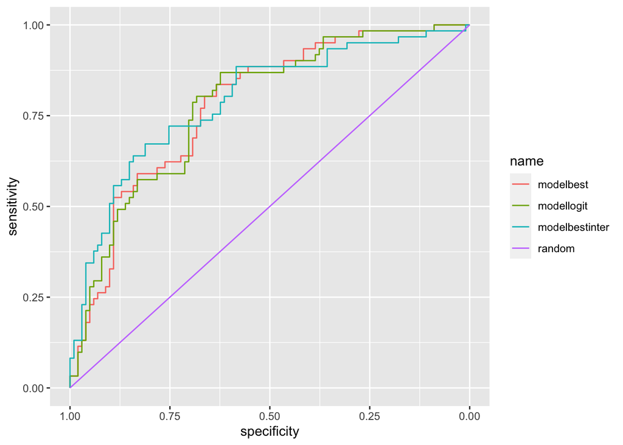

```r
library(pROC)
rocobj1 <- roc(dtest$chd, prev1)
rocobj2 <- roc(dtest$chd, prev2)
rocobj3 <- roc(dtest$chd, prev3)
rocobj4 <- roc(dtest$chd, prev4)

ggroc(list(modelbest=rocobj1, modellogit=rocobj2, modelbestinter=rocobj4, random=rocobj3))
```

Calcul des valeurs de AUC :

```r
rmarkdown::paged_table(data.frame(modelbest = round(auc(dtest$chd, prev1),4),
           modellogit = round(auc(dtest$chd, prev2),4),
           modelinter = round(auc(dtest$chd, prev4),4),
           random = round(auc(dtest$chd, prev3),4)))
```

| modelbest | modellogit | modelinter | random |
| --- | --- | --- | --- |
| 0.7801 | 0.7804 | 0.7916 | 0.5 |

# 2 Régression loglinéaire

Dans cette partie, on souhaite étudier la diversité des fourmis sur le site expérimental des Nourragues en Guyane Française. Les données, disponibles dans le fichier *Fourmis.txt*, sont issues du protocole expérimental suivant : des morceaux de 1$m^2$ de litière ont été récoltés. Ils ont été pesés (car le poids de litière est vu comme un indicateur de l’épaisseur de la litière) et le nombre d’espèces différentes présentes dans l’échantillon a été dénombré. Enfin les conditions de recueil (humides ou sèches) ont été notées pour tester leur influence sur la présence des fourmis. L’objectif est de mettre en évidence les variables qui influencent potentiellement le nombre d’espèces de fourmis présentes dans le milieu.

**Question 1.** Chargez le jeu de données *Fourmis* et faites quelques statistiques descritpives pour vous familiariser avec le jeu de données.

```r
Fourmis <- read.table("Fourmis.txt",header=T, sep=',')
Fourmis$Site=as.factor(Fourmis$Site)
Fourmis$Conditions=as.factor(Fourmis$Conditions)
summary(Fourmis)
```

```
   Effectifs         Weight         Site    Conditions
 Min.   : 2.00   Min.   : 6.200   FLWT:50   Dry:83
 1st Qu.: 7.00   1st Qu.: 8.525   FTWT:50   Wet:87
 Median :10.00   Median : 9.950   GPWT:50
 Mean   :11.19   Mean   :10.168   INWT:20
 3rd Qu.:15.00   3rd Qu.:11.600
 Max.   :28.00   Max.   :17.800
```

```r
Fourmis %>% group_by(Site, Conditions) %>% summarise(n())
```

```
# A tibble: 8 × 3
# Groups:   Site [4]
  Site  Conditions `n()`
  <fct> <fct>      <int>
1 FLWT  Dry           24
2 FLWT  Wet           26
3 FTWT  Dry           24
4 FTWT  Wet           26
5 GPWT  Dry           22
6 GPWT  Wet           28
7 INWT  Dry           13
8 INWT  Wet            7
```

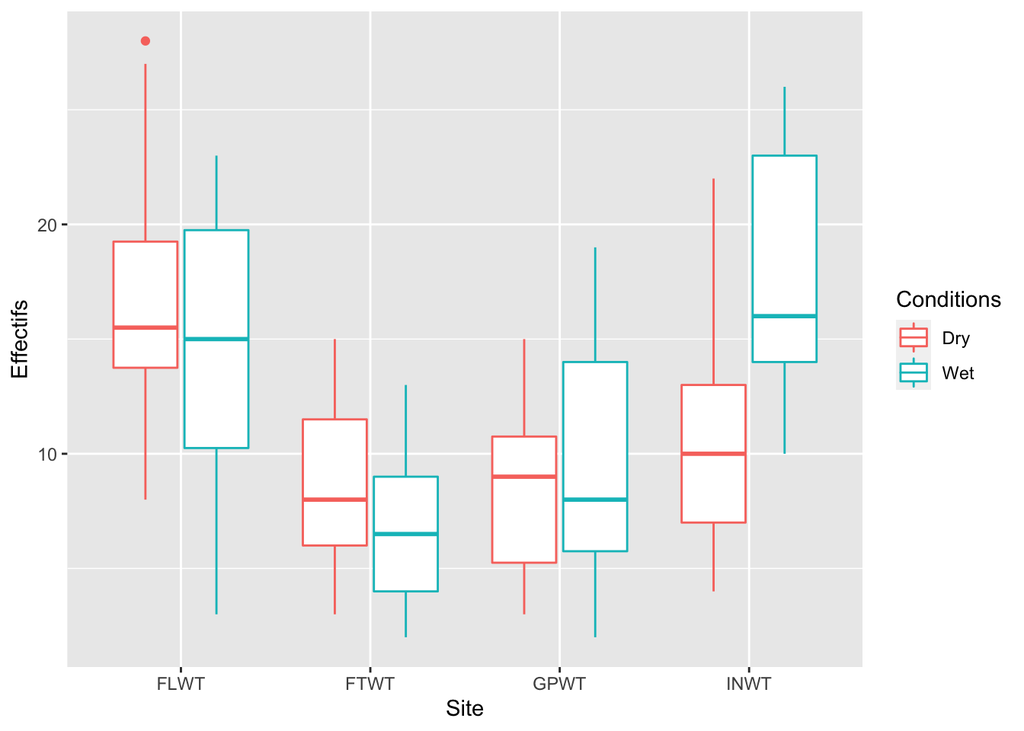

```r
ggplot(data= Fourmis, aes(x=Site, y=Effectifs, col= Conditions)) + geom_boxplot()
```

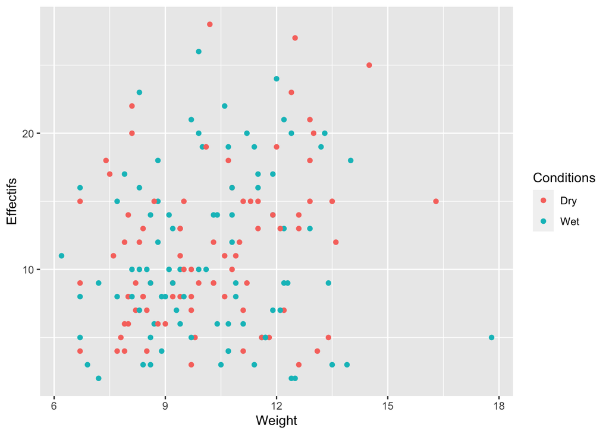

```r
ggplot(data= Fourmis, aes(x=Weight, y=Effectifs, col= Conditions)) + geom_point()
```

**Question 2.** Dans cette question, on cherche à expliquer le nombre de fourmis présentes dans un échantillon de sol en prenant en compte les conditions de recueil, le site et l’interaction entre ces deux facteurs.

**Question 2.a.** Ecrivez un modèle linéaire généralisé *modpois* adapté et programmez-le à l’aide de la fonction `glm()`.

$$Eff_i\sim\mathcal{P}(\lambda_i) \textrm{ et } \ln(\lambda_i) = \theta_0
+ \sum_{j\in S}(\theta_j + \gamma_j
\mathbb{1}_{Conditions_i=WET})\mathbb{1}_{Site_i=j} + \alpha
\mathbb{1}_{Conditions_i=WET}$$
avec $S=\{FTWT,GPWT,INTW\}$.

```r
modpois = glm(Effectifs~Site*Conditions,data=Fourmis,family=poisson)
summary(modpois)
```

```
Call:
glm(formula = Effectifs ~ Site * Conditions, family = poisson,
    data = Fourmis)

Deviance Residuals:
    Min       1Q   Median       3Q      Max
-3.7219  -1.2101  -0.2415   0.9066   2.9152

Coefficients:
                       Estimate Std. Error z value Pr(>|z|)
(Intercept)             2.82583    0.04969  56.869  < 2e-16 ***
SiteFTWT               -0.62861    0.08425  -7.461 8.60e-14 ***
SiteGPWT               -0.69113    0.08857  -7.803 6.06e-15 ***
SiteINWT               -0.42794    0.09727  -4.399 1.09e-05 ***
ConditionsWet          -0.13851    0.07132  -1.942   0.0521 .
SiteFTWT:ConditionsWet -0.17515    0.12476  -1.404   0.1603
SiteGPWT:ConditionsWet  0.28473    0.11880   2.397   0.0165 *
SiteINWT:ConditionsWet  0.63099    0.14148   4.460 8.20e-06 ***
---
Signif. codes:  0 '***' 0.001 '**' 0.01 '*' 0.05 '.' 0.1 ' ' 1

(Dispersion parameter for poisson family taken to be 1)

    Null deviance: 530.36  on 169  degrees of freedom
Residual deviance: 329.68  on 162  degrees of freedom
AIC: 1045.4

Number of Fisher Scoring iterations: 4
```

**Question 2.b.** Etudiez si on peut simplifier le modèle *modpois*

```r
anova(glm(Effectifs~Site+Conditions,data=Fourmis,family=poisson),modpois,test="Chisq")
```

```
Analysis of Deviance Table

Model 1: Effectifs ~ Site + Conditions
Model 2: Effectifs ~ Site * Conditions
  Resid. Df Resid. Dev Df Deviance  Pr(>Chi)
1       165     361.05
2       162     329.68  3   31.367 7.114e-07 ***
---
Signif. codes:  0 '***' 0.001 '**' 0.01 '*' 0.05 '.' 0.1 ' ' 1
```

On rejette l’hypothèse nulle, on conserve l’effet d’interaction.

**Question 2.c.** Quel est le nombre moyen d’espèces de fourmis attendu sur un échantillon de terre aux différents sites pour les deux conditions ?

```r
newx = data.frame(Site=rep(levels(Fourmis$Site),2),Conditions=rep(levels(Fourmis$Conditions),each=4))
newx=data.frame(newx,lambdahat=predict(modpois,newdata=newx,type="response"))
newx
```

```
  Site Conditions lambdahat
1 FLWT        Dry 16.875000
2 FTWT        Dry  9.000000
3 GPWT        Dry  8.454545
4 INWT        Dry 11.000000
5 FLWT        Wet 14.692308
6 FTWT        Wet  6.576923
7 GPWT        Wet  9.785714
8 INWT        Wet 18.000000
```

**Question 3.** On souhaite maintenant étudier le nombre d’espèces de fourmis présentes dans une unité de volume, en fonction des caractéristiques du site. Nous allons ici intégrer l’information du poids (*Weight*) qui est vu comme un indicateur de l’épaisseur de la litière.

**Question 3.a.** Ecrivez la relation entre les paramètres des lois de Poisson du nombre d’espèces présentes en un site et du nombre d’espèces présentes dans une unité de volume.

$$\mathbb{E}[\textrm{nb esp.}]=\mathbb{E}[\textrm{nb esp. par unité de
volume}]\times Weight$$

Déduisez-en un modèle pour le nombre d’espèces par unité de volume et analysez le rôle de la variable *Weight*.

$$Eff_i\sim\mathcal{P}(\lambda_i) \textrm{ et } \ln(\lambda_i) =
\ln(Weight_i) + \theta_0 + \sum_{j\in S}(\theta_j + \gamma_j
\mathbb{1}_{Conditions_i=WET})\mathbb{1}_{Site_i=j} + \alpha
\mathbb{1}_{Conditions_i=WET}$$
On ajuste ce modèle à l’aide de l’option `"offset"` de la fonction `glm()`.

```r
glmInt = glm(Effectifs~Site*Conditions,offset=log(Weight),family="poisson", data=Fourmis )
summary(glmInt)
```

```
Call:
glm(formula = Effectifs ~ Site * Conditions, family = "poisson",
    data = Fourmis, offset = log(Weight))

Deviance Residuals:
    Min       1Q   Median       3Q      Max
-3.2267  -0.9268  -0.1522   0.8252   3.6257

Coefficients:
                       Estimate Std. Error z value Pr(>|z|)
(Intercept)             0.49531    0.04969   9.968  < 2e-16 ***
SiteFTWT               -0.55200    0.08425  -6.552 5.69e-11 ***
SiteGPWT               -0.74225    0.08857  -8.380  < 2e-16 ***
SiteINWT               -0.38293    0.09727  -3.937 8.26e-05 ***
ConditionsWet          -0.02802    0.07132  -0.393  0.69438
SiteFTWT:ConditionsWet -0.37426    0.12476  -3.000  0.00270 **
SiteGPWT:ConditionsWet  0.16746    0.11880   1.410  0.15866
SiteINWT:ConditionsWet  0.47387    0.14148   3.349  0.00081 ***
---
Signif. codes:  0 '***' 0.001 '**' 0.01 '*' 0.05 '.' 0.1 ' ' 1

(Dispersion parameter for poisson family taken to be 1)

    Null deviance: 534.13  on 169  degrees of freedom
Residual deviance: 301.41  on 162  degrees of freedom
AIC: 1017.2

Number of Fisher Scoring iterations: 4
```

**Question 3.b.** Quelle est la densité d’espèces de fourmis prédite pour les quatre forêts pour les deux conditions ?

Le nombre d’espèces de fourmis par unité de volume (donc pour un poids d’1kg de litière)

```r
newx = data.frame(Site=rep(levels(Fourmis$Site),2),Conditions=rep(levels(Fourmis$Conditions),each=4),Weight=rep(1,8))
newx=data.frame(newx,lambdahat=predict(glmInt,newdata=newx,type="response"))
newx
```

```
  Site Conditions Weight lambdahat
1 FLWT        Dry      1 1.6410049
2 FTWT        Dry      1 0.9448819
3 GPWT        Dry      1 0.7811844
4 INWT        Dry      1 1.1189358
5 FLWT        Wet      1 1.5956558
6 FTWT        Wet      1 0.6319290
7 GPWT        Wet      1 0.8980662
8 INWT        Wet      1 1.7475728
```

**Question 3.c.** Quel est le nombre moyen d’espèces de fourmis attendu sur un échantillon de terre qui pèse 10kg aux différents sites pour les deux conditions ?

```r
newx = data.frame(Site=rep(levels(Fourmis$Site),2),Conditions=rep(levels(Fourmis$Conditions),each=4),Weight=rep(10,8))

newx=data.frame(newx,lambdahat=predict(glmInt,newdata=newx,type="response"))
newx
```

```
  Site Conditions Weight lambdahat
1 FLWT        Dry     10 16.410049
2 FTWT        Dry     10  9.448819
3 GPWT        Dry     10  7.811844
4 INWT        Dry     10 11.189358
5 FLWT        Wet     10 15.956558
6 FTWT        Wet     10  6.319290
7 GPWT        Wet     10  8.980662
8 INWT        Wet     10 17.475728
```

**Question 4.** Est-ce-qu’une modélisation avec un modèle binomial négatif est plus appropriée ?

Utilisation de la famille quasipoisson de la fonction `glm()` :

```r
modbinneg<-glm(Effectifs~Site*Conditions,offset=log(Weight),family=quasipoisson(link="log"), data=Fourmis )
summary(modbinneg)
```

```
Call:
glm(formula = Effectifs ~ Site * Conditions, family = quasipoisson(link = "log"),
    data = Fourmis, offset = log(Weight))

Deviance Residuals:
    Min       1Q   Median       3Q      Max
-3.2267  -0.9268  -0.1522   0.8252   3.6257

Coefficients:
                       Estimate Std. Error t value Pr(>|t|)
(Intercept)             0.49531    0.06739   7.350 9.23e-12 ***
SiteFTWT               -0.55200    0.11426  -4.831 3.12e-06 ***
SiteGPWT               -0.74225    0.12012  -6.179 5.02e-09 ***
SiteINWT               -0.38293    0.13191  -2.903  0.00421 **
ConditionsWet          -0.02802    0.09672  -0.290  0.77239
SiteFTWT:ConditionsWet -0.37426    0.16918  -2.212  0.02836 *
SiteGPWT:ConditionsWet  0.16746    0.16110   1.039  0.30015
SiteINWT:ConditionsWet  0.47387    0.19186   2.470  0.01455 *
---
Signif. codes:  0 '***' 0.001 '**' 0.01 '*' 0.05 '.' 0.1 ' ' 1

(Dispersion parameter for quasipoisson family taken to be 1.839056)

    Null deviance: 534.13  on 169  degrees of freedom
Residual deviance: 301.41  on 162  degrees of freedom
AIC: NA

Number of Fisher Scoring iterations: 4
```

Utilisation de la fonction `glm.nb()` de la librairie `MASS` pour ajuster un modèle binomila négatif avec offset :

```r
library(MASS)
FourmisBis=data.frame(Fourmis, lnweight=log(Fourmis$Weight))
summary(glm.nb(Effectifs ~ Site * Conditions+offset(lnweight),data = FourmisBis))
```

```
Call:
glm.nb(formula = Effectifs ~ Site * Conditions + offset(lnweight),
    data = FourmisBis, init.theta = 14.82825309, link = log)

Deviance Residuals:
    Min       1Q   Median       3Q      Max
-2.5865  -0.7093  -0.1270   0.6462   2.6344

Coefficients:
                       Estimate Std. Error z value Pr(>|z|)
(Intercept)             0.49875    0.07293   6.838 8.01e-12 ***
SiteFTWT               -0.56062    0.11330  -4.948 7.49e-07 ***
SiteGPWT               -0.73451    0.11738  -6.257 3.91e-10 ***
SiteINWT               -0.37349    0.13243  -2.820   0.0048 **
ConditionsWet          -0.02961    0.10285  -0.288   0.7734
SiteFTWT:ConditionsWet -0.35371    0.16279  -2.173   0.0298 *
SiteGPWT:ConditionsWet  0.16137    0.15858   1.018   0.3089
SiteINWT:ConditionsWet  0.45777    0.20117   2.276   0.0229 *
---
Signif. codes:  0 '***' 0.001 '**' 0.01 '*' 0.05 '.' 0.1 ' ' 1

(Dispersion parameter for Negative Binomial(14.8283) family taken to be 1)

    Null deviance: 310.35  on 169  degrees of freedom
Residual deviance: 181.80  on 162  degrees of freedom
AIC: 991.71

Number of Fisher Scoring iterations: 1

              Theta:  14.83
          Std. Err.:  4.08

 2 x log-likelihood:  -973.71
```

# 3 Exemple de régression polytomique

L’objectif est d’expliquer l’hypertension artérielle des patients à partir de leurs caractéristiques physiologiques, cliniques et comportementales : le sexe, fumer ou pas, effectuer régulièrement des exercices physiques, etc. La variable réponse est au départ la pression systolique (SYSTOLIC). Elle est découpée en 4 niveaux :

- 1 : tension normale si PA systolique < 140 mm hg
- 2 : hypertension élevée si PA systolique $\in ]140, 160]$ mm hg
- 3 : hypertension très élevée si PA systolique$\in ]160, 180]$ mm hg
- 4 : hypertension sévère si PA systolique > 180 mm hg

**Question 1.** Récupérez les données dans le fichier *hypertension.txt* et faites quelques statistiques descriptives pour vous familiariser avec le jeu de données.

```r
hypertension<-read.table("hypertension.txt",header=T,colClasses=rep("factor",10))
summary(hypertension)
```

```
 niveau  homme   fumeur  exercice surpoids alcool  stress  sel     revenu
 1:168   0:217   0:193   1:151    1:162    1:129   1:125   1:130   1:140
 2: 98   1:182   1:206   2:113    2: 78    2:141   2:140   2:126   2:140
 3: 69                   3:135    3:159    3:129   3:134   3:143   3:119
 4: 64
 education
 1:136
 2:126
 3:137
```

```r
head(hypertension)
```

```
  niveau homme fumeur exercice surpoids alcool stress sel revenu education
1      2     0      0        1        1      1      2   1      1         3
2      1     0      0        3        1      1      3   2      3         1
3      1     0      1        2        1      2      2   2      1         2
4      1     1      0        1        3      2      3   3      3         1
5      1     0      1        3        1      2      2   1      1         1
6      1     0      1        2        1      3      1   2      2         2
```

```r
dim(hypertension)
```

```
[1] 399  10
```

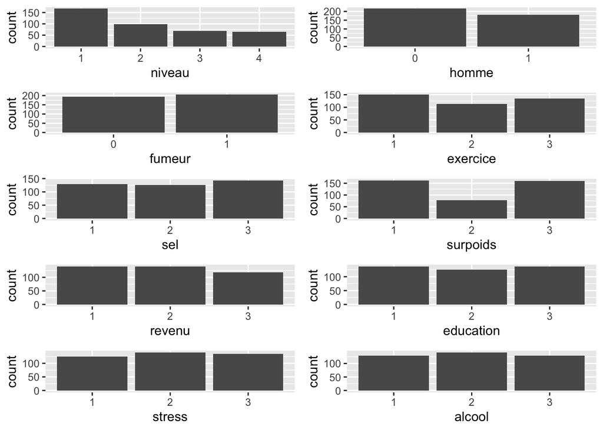

**Question 2.** A l’aide de la commande suivante, on peut ajuster un modèle de **régression polytomique non ordonnée** dont la dernière modalité est prise comme référence :

```r
modelnonord <-vglm(niveau ~ ., data = hypertension, family = multinomial)
```

Le modèle s’écrit sous la forme
$$\ln(\frac{\pi_m(x_i)}{\pi_4(x_i)})= x_i \theta^{(m)}$$

où $\pi_m$ dénote la probabilité de prendre la modalité $m$ pour les 4 niveaux de la pression systolique, $x_i$ est le vecteur des valeurs observées pour le $i$ème individu sur les variables explicatives et $\theta^{(m)}=(\theta_0^{(m)},\ldots,\theta_k^{(m)})'$.

```r
summary(modelnonord)
```

```
Call:
vglm(formula = niveau ~ ., family = multinomial, data = hypertension)

Coefficients:
               Estimate Std. Error z value Pr(>|z|)
(Intercept):1  3.157762   0.770442   4.099 4.16e-05 ***
(Intercept):2  2.030483   0.810241   2.506 0.012210 *
(Intercept):3  0.713997   0.858395   0.832 0.405533
homme1:1       0.050576   0.342541   0.148 0.882620
homme1:2      -0.414095   0.363032  -1.141 0.254012
homme1:3       0.090932   0.376672   0.241 0.809238
fumeur1:1     -1.177530   0.358440  -3.285 0.001019 **
fumeur1:2     -1.235962   0.374375  -3.301 0.000962 ***
fumeur1:3     -0.312209   0.394786  -0.791 0.429043
exercice2:1    1.326346   0.438071   3.028 0.002464 **
exercice2:2    0.860507   0.443240   1.941 0.052209 .
exercice2:3    0.751686   0.473894   1.586 0.112696
exercice3:1    1.324560   0.400999   3.303 0.000956 ***
exercice3:2    0.213364   0.427436   0.499 0.617658
exercice3:3    0.596719   0.436967   1.366 0.172067
 [ getOption("max.print") est atteint -- 36 lignes omises ]
---
Signif. codes:  0 '***' 0.001 '**' 0.01 '*' 0.05 '.' 0.1 ' ' 1

Names of linear predictors: log(mu[,1]/mu[,4]), log(mu[,2]/mu[,4]),
log(mu[,3]/mu[,4])

Residual deviance: 924.0181 on 1146 degrees of freedom

Log-likelihood: -462.0091 on 1146 degrees of freedom

Number of Fisher scoring iterations: 5

No Hauck-Donner effect found in any of the estimates


Reference group is level  4  of the response
```

**Question 3.** Comme les modalités de la pression systolique ont un ordre naturel, il est préférable de considérer un modèle reliant les $\pi_m$ pour deux modalités successives. On va donc ajuster un modèle de **régression polytomique ordonnée** sur les logits adjacents à l’aide de la commande suivante :

```r
# transformation en variable ordinale
hypertension$niveau = factor(hypertension$niveau, order = TRUE, levels = c("1", "2", "3","4"))
# ajustement du modèle
modelord <- vglm(niveau ~ ., data = hypertension, family = acat())
```

Le modèle s’écrit sous la forme

$$ln[\pi_{m+1}(x_i)/\pi_{m}(x_i)] = x_i \theta^{(m)}$$
avec $\theta^{(m)}=(\theta_0^{(m)},\ldots,\theta_k^{(m)})'$.

```r
summary(modelord)
```

```
Call:
vglm(formula = niveau ~ ., family = acat(), data = hypertension)

Coefficients:
               Estimate Std. Error z value Pr(>|z|)
(Intercept):1 -1.127279   0.556058  -2.027 0.042635 *
(Intercept):2 -1.316487   0.724426  -1.817 0.069174 .
(Intercept):3 -0.713997   0.858395  -0.832 0.405533
homme1:1      -0.464670   0.281889  -1.648 0.099267 .
homme1:2       0.505027   0.340765   1.482 0.138330
homme1:3      -0.090932   0.376672  -0.241 0.809238
fumeur1:1     -0.058432   0.283060  -0.206 0.836456
fumeur1:2      0.923752   0.344960   2.678 0.007409 **
fumeur1:3      0.312209   0.394786   0.791 0.429043
exercice2:1   -0.465839   0.331721  -1.404 0.160226
exercice2:2   -0.108821   0.403945  -0.269 0.787626
exercice2:3   -0.751686   0.473894  -1.586 0.112696
exercice3:1   -1.111196   0.336452  -3.303 0.000958 ***
exercice3:2    0.383355   0.400320   0.958 0.338254
exercice3:3   -0.596719   0.436967  -1.366 0.172067
 [ getOption("max.print") est atteint -- 36 lignes omises ]
---
Signif. codes:  0 '***' 0.001 '**' 0.01 '*' 0.05 '.' 0.1 ' ' 1

Names of linear predictors: loglink(P[Y=2]/P[Y=1]), loglink(P[Y=3]/P[Y=2]),
loglink(P[Y=4]/P[Y=3])

Residual deviance: 924.0181 on 1146 degrees of freedom

Log-likelihood: -462.0091 on 1146 degrees of freedom

Number of Fisher scoring iterations: 5

No Hauck-Donner effect found in any of the estimates
```

**Question 4.** Dans cette question, on s’intéresse à l’interprétation des paramètres. On prend ici l’exemple de la valeur $0.923752$ dans le `summary(modelord)` pour la variable fumeur. Reliez cette valeur à l’ une interprétation en odds ratio.

On peut écrire que

$$\ln\left[ \frac{P(Y=3|fumeur=1,....)}{P(Y=2|fumeur=1,....)}\right] -
\ln\left[\frac{P(Y=3|fumeur=0,....)}{P(Y=2|fumeur=0,....)}\right] =
\theta_0^{(m=2)}+\theta_2^{(m=2)} - \theta_0^{(m=2)}$$
OR(Y=3 vs Y=2 |fumeur) = exp(0.923752)=2.52
Les fumeurs ont 2.52 fois plus de chances que les non-fumeurs d’être dans le niveau 3 plutôt que dans le niveau 2.

**Question 5.** Sauf si c’est le but explicite de l’étude, évaluer les influences niveau par niveau est très difficile. On va considérer le modèle simplifié où les coefficients des variables explicatives sont les mêmes quelque soit le niveau étudié c.-à-d. chaque variable explicative agit de la même manière sur la variable expliquée quel que soit le niveau k. Le modèle devient

$$ln[\pi_{m+1}(x)/\pi_{m}(x)] =
\theta_0^{(m)} + \theta_1 x^{(1)}+ \ldots+ \theta_p x^{(p)}$$

```r
modelordparal <- vglm(niveau ~ ., data = hypertension, family = acat(parallel=TRUE))
summary(modelordparal)
```

```
Call:
vglm(formula = niveau ~ ., family = acat(parallel = TRUE), data = hypertension)

Coefficients:
               Estimate Std. Error z value Pr(>|z|)
(Intercept):1 -1.105439   0.244130  -4.528 5.95e-06 ***
(Intercept):2 -1.101920   0.274182  -4.019 5.85e-05 ***
(Intercept):3 -1.008707   0.299681  -3.366 0.000763 ***
homme1         0.001539   0.104353   0.015 0.988233
fumeur1        0.411860   0.107358   3.836 0.000125 ***
exercice2     -0.379661   0.128983  -2.943 0.003245 **
exercice3     -0.412074   0.123175  -3.345 0.000822 ***
surpoids2      0.386041   0.144025   2.680 0.007354 **
surpoids3      0.680966   0.122201   5.572 2.51e-08 ***
alcool2        0.011922   0.128494   0.093 0.926078
alcool3        0.524565   0.131532   3.988 6.66e-05 ***
stress2        0.028177   0.126568   0.223 0.823829
stress3        0.106025   0.127043   0.835 0.403965
sel2           0.047370   0.128323   0.369 0.712020
sel3           0.030460   0.125299   0.243 0.807928
 [ getOption("max.print") est atteint -- 4 lignes omises ]
---
Signif. codes:  0 '***' 0.001 '**' 0.01 '*' 0.05 '.' 0.1 ' ' 1

Names of linear predictors: loglink(P[Y=2]/P[Y=1]), loglink(P[Y=3]/P[Y=2]),
loglink(P[Y=4]/P[Y=3])

Residual deviance: 961.1625 on 1178 degrees of freedom

Log-likelihood: -480.5813 on 1178 degrees of freedom

Number of Fisher scoring iterations: 5

No Hauck-Donner effect found in any of the estimates
```

Nous n’avons plus qu’un seul coefficient par variable, on peut mieux situer leur rôle. Reprenons l’exemple de FUMEUR. Il agit positivement (+0.41) sur le surcroît de chances d’augmenter le niveau d’hypertension, l’odds ratio associé est EXP(0.41) = 1.5 c.-à-d. un fumeur a 1.5 fois plus de chances d’être au niveau directement au dessus d’hypertension qu’un non fumeur, et ceci quelque soit son niveau actuel d’hypertension.

**Question 6.** A l’aide de `modelordparal@fitted.values[13,]`, décrivez les résultats pour le 13ème individu. Quelle est la probabilité que cet individu soit hypertendu ?

```r
hypertension[13,]
```

```
   niveau homme fumeur exercice surpoids alcool stress sel revenu education
13      3     0      1        1        3      3      1   2      3         3
```

```r
pi_indiv<-modelordparal@fitted.values[13,]
print(pi_indiv)
```

```
        1         2         3         4
0.0482529 0.1081393 0.2432049 0.6004029
```

```r
print(cumsum(rev(pi_indiv)))
```

```
        4         3         2         1
0.6004029 0.8436078 0.9517471 1.0000000
```

Si on regarde le 13ème individu, on récupère les $\widehat{\pi}(x_{13})$. Nous apprenons que cette femme a 60 % de chances de présenter une hypertension de niveau 4; elle a 95% de chances d’être hypertendue (niveau >= 2). Vu ses caractéristiques, c’était prévisible.

**Question 7.** A l’aide de la fonction `lrtest()`, faites un test de sous-modèle pour comparer les modèles *modelord* et *modordparal*.

```r
lrtest( modelordparal,modelord)
```

```
Likelihood ratio test

Model 1: niveau ~ .
Model 2: niveau ~ .
   #Df  LogLik  Df  Chisq Pr(>Chisq)
1 1178 -480.58
2 1146 -462.01 -32 37.144     0.2439
```

**Question 8.** Dans cette question, la variable niveau est transformée en une variable binaire : 1 si hypertension (PA systolique > 140), 0 si tension normale.

```r
hypertensionbis=hypertension
hypertensionbis$niveau = (hypertension$niveau != 1)
```

Proposez un modèle pour expliquer la présence d’hypertension en fonction des autres variables. Peut-on simplifier ce modèle ? Etudiez la puissance d’ajustement de ce modèle, …

```r
modbin=glm(niveau~.,data=hypertensionbis,family="binomial")
summary(modbin)
```

```
Call:
glm(formula = niveau ~ ., family = "binomial", data = hypertensionbis)

Deviance Residuals:
    Min       1Q   Median       3Q      Max
-2.2837  -1.0753   0.5982   0.9600   1.6886

Coefficients:
            Estimate Std. Error z value Pr(>|z|)
(Intercept) -0.79902    0.45978  -1.738 0.082242 .
homme1      -0.20897    0.22691  -0.921 0.357097
fumeur1      0.51379    0.22944   2.239 0.025138 *
exercice2   -0.66878    0.28185  -2.373 0.017651 *
exercice3   -1.02526    0.26854  -3.818 0.000135 ***
surpoids2    0.48916    0.29653   1.650 0.099015 .
surpoids3    1.28477    0.25672   5.004  5.6e-07 ***
alcool2     -0.06407    0.26884  -0.238 0.811645
alcool3      0.73967    0.28374   2.607 0.009139 **
stress2      0.34297    0.27281   1.257 0.208681
stress3      0.54575    0.27549   1.981 0.047588 *
sel2         0.05469    0.28136   0.194 0.845885
sel3         0.05155    0.27181   0.190 0.849576
revenu2      0.35759    0.26648   1.342 0.179626
revenu3      0.60325    0.28351   2.128 0.033354 *
 [ getOption("max.print") est atteint -- 2 lignes omises ]
---
Signif. codes:  0 '***' 0.001 '**' 0.01 '*' 0.05 '.' 0.1 ' ' 1

(Dispersion parameter for binomial family taken to be 1)

    Null deviance: 543.14  on 398  degrees of freedom
Residual deviance: 481.77  on 382  degrees of freedom
AIC: 515.77

Number of Fisher Scoring iterations: 4
```

```r
modbinbest = step(modbin)
```

```
Start:  AIC=515.77
niveau ~ homme + fumeur + exercice + surpoids + alcool + stress +
    sel + revenu + education

            Df Deviance    AIC
- sel        2   481.81 511.81
- education  2   481.98 511.98
- homme      1   482.62 514.62
<none>           481.77 515.77
- stress     2   485.79 515.79
- revenu     2   486.49 516.49
- fumeur     1   486.83 518.83
- alcool     2   492.08 522.08
- exercice   2   497.37 527.37
- surpoids   2   508.59 538.59

Step:  AIC=511.81
niveau ~ homme + fumeur + exercice + surpoids + alcool + stress +
    revenu + education

            Df Deviance    AIC
- education  2   482.02 508.02
- homme      1   482.68 510.68
<none>           481.81 511.81
- stress     2   485.82 511.82
- revenu     2   486.56 512.56
- fumeur     1   486.89 514.89
- alcool     2   492.11 518.11
- exercice   2   497.49 523.49
- surpoids   2   508.70 534.70

Step:  AIC=508.02
niveau ~ homme + fumeur + exercice + surpoids + alcool + stress +
    revenu

           Df Deviance    AIC
- homme     1   483.01 507.01
<none>          482.02 508.02
- stress    2   486.10 508.10
- revenu    2   486.69 508.69
- fumeur    1   487.04 511.04
- alcool    2   492.27 514.27
- exercice  2   497.86 519.86
- surpoids  2   508.92 530.92

Step:  AIC=507.01
niveau ~ fumeur + exercice + surpoids + alcool + stress + revenu

           Df Deviance    AIC
<none>          483.01 507.01
- stress    2   487.09 507.09
- revenu    2   487.43 507.43
- fumeur    1   488.30 510.30
- alcool    2   493.53 513.53
- exercice  2   498.51 518.51
- surpoids  2   509.81 529.81
```